# Step 5 — Clustering and Cell Annotation

Jackson & Fischer et al. (2020) Breast Cancer | imcdatasets

Author

mass-cytometry-explorations

Published

November 14, 2026

## 1 Overview

This notebook performs **Step 5** of the analysis: it groups cells using their principal-component (PCA) coordinates, summarizes marker expression for each cluster, and adds optional manual cell-type labels. Clusters are exploratory groups, not automatically discovered biological cell types; inspect their marker profiles and validate labels against domain knowledge before interpreting them.

Inputs from Step 4:

- `results/sce_dimensionality_reduced.rds`

Outputs from this notebook:

- `results/clustering_summary/clustering_parameters.csv`
- `results/clustering_summary/cluster_sizes.csv`
- `results/clustering_summary/marker_means_by_cluster.csv`
- `results/clustering_summary/cluster_annotation_template.csv`
- `results/sce_clustered_annotated.rds`

The annotation template is created on the first render. Review the per-cluster marker means, fill in the template’s `annotation` column with cell-type labels, then render this notebook again to save those labels with the cells.

## 2 Setup

```r
# Load the SCE accessors used to read and update the saved single-cell object.
suppressPackageStartupMessages({
  library(SingleCellExperiment)
  # ggplot2 provides the cluster visualization figures below.
  library(ggplot2)
})

# Resolve the notebooks directory so paths work from the repository root or
# when the notebook is rendered with notebooks/ as the current directory.
if (basename(getwd()) == "notebooks") {
  notebooks_dir <- normalizePath(getwd())
} else if (dir.exists(file.path(getwd(), "notebooks"))) {
  notebooks_dir <- normalizePath(file.path(getwd(), "notebooks"))
} else {
  # Fail early rather than silently writing outputs to an unexpected location.
  stop("Run from project root or notebooks/ directory.")
}

# Use one predictable base directory for all relative input and output paths.
if (!identical(normalizePath(getwd()), notebooks_dir)) {
  setwd(notebooks_dir)
}

# Record the working directory in the rendered report for reproducibility.
cat("Working directory:", getwd(), "\n")
```

```
Working directory: /home/lizalfos/mass-cytometry-explorations/notebooks
```

```r
# Keep all machine-readable summaries for this step together.
dir.create(file.path("..", "results", "clustering_summary"),
           recursive = TRUE, showWarnings = FALSE)
# Create the step-specific figure directory for future saved figures.
dir.create(file.path("..", "figures", "05_clustering_annotation"),
           recursive = TRUE, showWarnings = FALSE)
```

## 3 Load the PCA and UMAP object

```r
# Step 4 saves both the original cell data and reduced dimensions in this object.
sce_path <- file.path("..", "results", "sce_dimensionality_reduced.rds")
if (!file.exists(sce_path)) {
  stop("Missing results/sce_dimensionality_reduced.rds. Please render notebooks/04_dimensionality_reduction.qmd first.")
}

# Loading the saved object preserves the exact cell order for clustering and
# writing cluster labels back into colData.
sce_clustered <- readRDS(sce_path)

# Verify the expected PCA embedding exists and has at least two dimensions.
if (!"PCA" %in% reducedDimNames(sce_clustered)) {
  stop("The input object does not contain a PCA reduced dimension.")
}
pca_embedding <- reducedDim(sce_clustered, "PCA")
if (ncol(pca_embedding) < 2L) {
  stop("PCA must contain at least two components to cluster and visualize cells.")
}

# Show the object and its available embeddings for an initial sanity check.
cat("Cells:", ncol(sce_clustered), "\n")
```

```
Cells: 272975
```

```r
cat("Markers:", nrow(sce_clustered), "\n")
```

```
Markers: 42
```

```r
cat("Reduced dimensions:", paste(reducedDimNames(sce_clustered), collapse = ", "), "\n")
```

```
Reduced dimensions: PCA, UMAP
```

## 4 Configure clustering

We use base R’s k-means algorithm on the leading PCA coordinates. PCA provides a compact representation of correlated marker measurements, while avoiding the common mistake of treating the two-dimensional UMAP layout as a quantitative distance space. UMAP is used below only to visualize the resulting labels.

The number of clusters and number of PCs are analysis choices, not universal truths. Change them below, compare alternative settings, and inspect cluster sizes and marker profiles. The chosen values and random seed are recorded in the output parameter table.

```r
# Number of clusters to estimate; adjust after exploring cluster diagnostics.
n_clusters <- 20L
# Use up to the first 15 PCs, or fewer if Step 4 produced fewer components.
n_pcs_for_clustering <- min(15L, ncol(pca_embedding))
# Fix the seed so repeated renders with the same inputs and settings are stable.
clustering_seed <- 2026L
# Multiple starts reduce dependence on one random initialization.
kmeans_nstart <- 5L
# Limit iteration count while allowing ordinary datasets to converge.
kmeans_iter_max <- 100L

# Guard against invalid settings before starting a potentially expensive fit.
if (nrow(pca_embedding) <= n_clusters) {
  stop("The number of cells must be greater than n_clusters.")
}
if (n_clusters < 2L) {
  stop("n_clusters must be at least 2.")
}

# Extract only the selected leading PCs to bound clustering memory and runtime.
pca_for_clustering <- pca_embedding[, seq_len(n_pcs_for_clustering), drop = FALSE]
if (any(!is.finite(pca_for_clustering))) {
  stop("The selected PCA coordinates contain missing or non-finite values.")
}

cat("Clustering", nrow(pca_for_clustering), "cells using",
    ncol(pca_for_clustering), "PCs into", n_clusters, "clusters.\n")
```

```
Clustering 272975 cells using 15 PCs into 20 clusters.
```

## 5 Cluster cells in PCA space

```r
# Seed k-means to make its random starting centers reproducible.
set.seed(clustering_seed)

# Treat each row as one cell and each selected PC as a clustering feature.
kmeans_fit <- stats::kmeans(
  x = pca_for_clustering,
  centers = n_clusters,
  iter.max = kmeans_iter_max,
  nstart = kmeans_nstart,
  algorithm = "Lloyd"
)

# Give cluster IDs stable, readable names for tables, plots, and colData.
cluster_levels <- sprintf("Cluster_%02d", seq_len(n_clusters))
cluster_id <- factor(
  cluster_levels[kmeans_fit$cluster],
  levels = cluster_levels
)

# Store one cluster ID per cell in the SCE so downstream steps can reuse it.
colData(sce_clustered)$cluster_id <- cluster_id

# Summarize cell counts, including any empty levels for a complete cluster list.
cluster_sizes <- as.data.frame(table(cluster_id), stringsAsFactors = FALSE)
names(cluster_sizes) <- c("cluster_id", "n_cells")
cluster_sizes$percent_cells <- 100 * cluster_sizes$n_cells / ncol(sce_clustered)
cluster_sizes
```

```
   cluster_id n_cells percent_cells
1  Cluster_01   12941      4.740727
2  Cluster_02   13814      5.060537
3  Cluster_03   13333      4.884330
4  Cluster_04    6144      2.250756
5  Cluster_05    6584      2.411942
6  Cluster_06   13466      4.933052
7  Cluster_07   18928      6.933968
8  Cluster_08    6649      2.435754
9  Cluster_09   20882      7.649785
10 Cluster_10   27400     10.037549
11 Cluster_11   13117      4.805202
12 Cluster_12   23061      8.448026
13 Cluster_13    4907      1.797601
14 Cluster_14   17129      6.274934
15 Cluster_15   18301      6.704277
16 Cluster_16    3650      1.337119
17 Cluster_17   18846      6.903929
18 Cluster_18   12299      4.505541
19 Cluster_19   10851      3.975089
20 Cluster_20   10673      3.909882
```

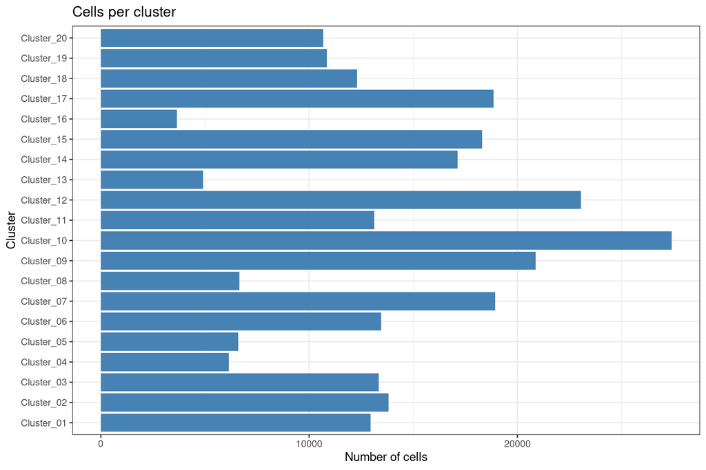

Figure 1: Number of cells assigned to each PCA-space cluster.

```r
# Plot cluster sizes to make highly imbalanced or unexpectedly small groups visible.
ggplot(cluster_sizes, aes(x = cluster_id, y = n_cells)) +
  geom_col(fill = "steelblue") +
  coord_flip() +
  labs(
    title = "Cells per cluster",
    x = "Cluster",
    y = "Number of cells"
  ) +
  theme_bw()
```

## 6 Visualize clusters on the embeddings

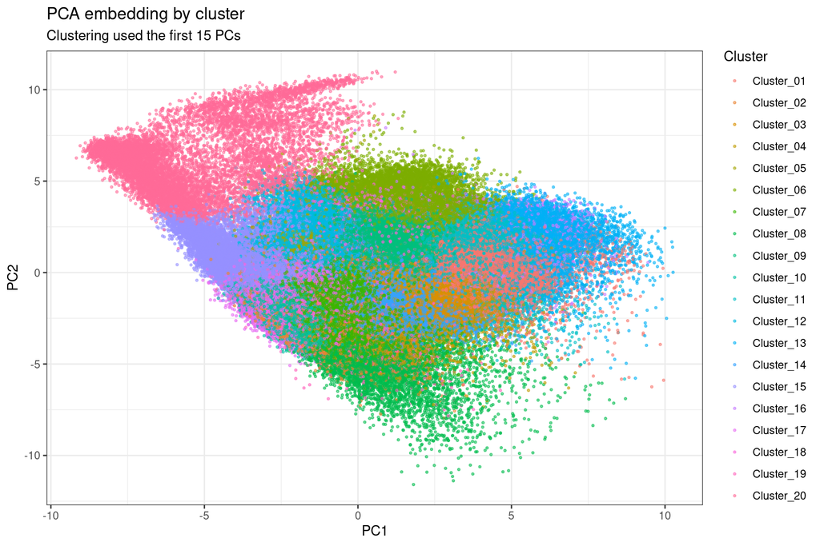

Figure 2: PCA embedding coloured by the k-means cluster assignments.

```r
# Plot the first two PCA axes; this is a diagnostic view, not the full clustering space.
pca_plot_df <- data.frame(
  PC1 = pca_embedding[, 1],
  PC2 = pca_embedding[, 2],
  cluster_id = cluster_id
)

ggplot(pca_plot_df, aes(x = PC1, y = PC2, colour = cluster_id)) +
  geom_point(alpha = 0.55, size = 0.6) +
  labs(
    title = "PCA embedding by cluster",
    subtitle = sprintf("Clustering used the first %d PCs", n_pcs_for_clustering),
    x = "PC1",
    y = "PC2",
    colour = "Cluster"
  ) +
  theme_bw()
```

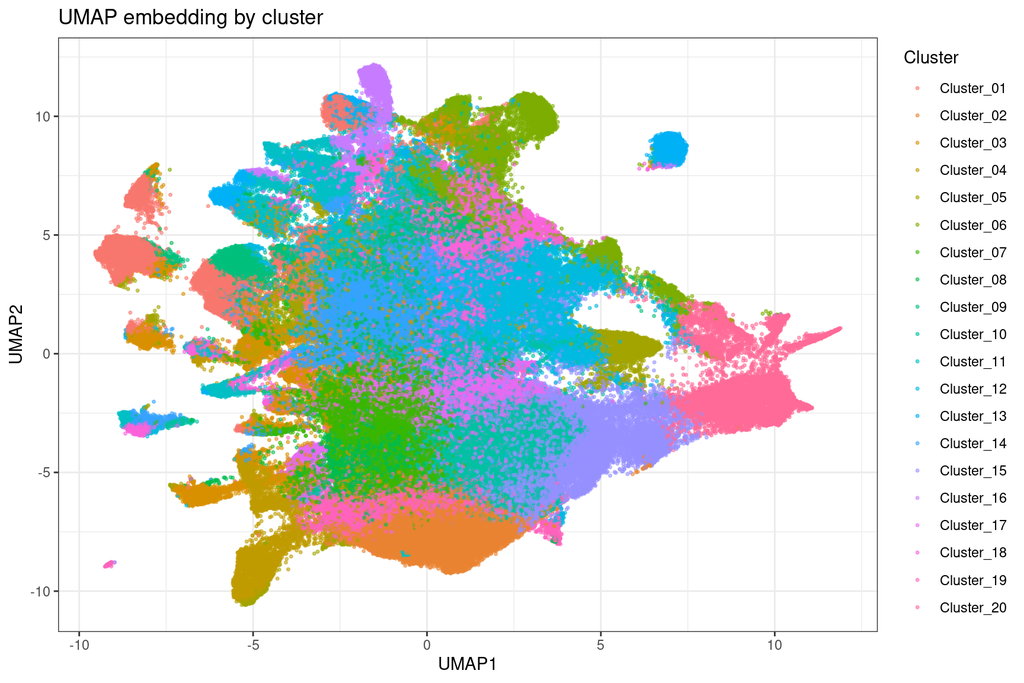

Figure 3: UMAP embedding coloured by the PCA-space cluster assignments, when available.

```r
# UMAP can show neighborhood structure, but its axes and distances are not used
# to compute the k-means clusters.
if ("UMAP" %in% reducedDimNames(sce_clustered)) {
  umap_embedding <- reducedDim(sce_clustered, "UMAP")
  if (ncol(umap_embedding) >= 2L) {
    umap_plot_df <- data.frame(
      UMAP1 = umap_embedding[, 1],
      UMAP2 = umap_embedding[, 2],
      cluster_id = cluster_id
    )

    ggplot(umap_plot_df, aes(x = UMAP1, y = UMAP2, colour = cluster_id)) +
      geom_point(alpha = 0.55, size = 0.6) +
      labs(
        title = "UMAP embedding by cluster",
        x = "UMAP1",
        y = "UMAP2",
        colour = "Cluster"
      ) +
      theme_bw()
  } else {
    plot.new()
    text(0.5, 0.5, "UMAP is present but has fewer than two dimensions.")
  }
} else {
  # Keep the document informative when the optional UMAP calculation failed upstream.
  plot.new()
  text(0.5, 0.5, "UMAP was not computed in Step 4; PCA clustering is still available.")
}
```

## 7 Summarize marker expression by cluster

Marker expression profiles help guide biological interpretation of each cluster. The summary below reports mean values in the preprocessing assay (for example, asinh-transformed expression). It is a descriptive aid, not an automatic cell-type classifier; marker combinations and relevant biological context should be considered when assigning labels.

```r
# Reuse the assay selected in preprocessing whenever that metadata is available.
analysis_assay <- metadata(sce_clustered)$preprocessing$analysis_assay
if (is.null(analysis_assay) || !analysis_assay %in% assayNames(sce_clustered)) {
  # For older or externally produced objects, use a familiar expression assay.
  assay_candidates <- c("exprs", "quant_norm", "counts", "scaled")
  available_candidates <- assay_candidates[assay_candidates %in% assayNames(sce_clustered)]
  if (length(available_candidates) == 0L) {
    stop("No supported assay is available for cluster marker summaries.")
  }
  analysis_assay <- available_candidates[1]
}

# Calculate each cluster's marker means separately to avoid materializing an
# additional full cell-by-marker copy of the assay.
cluster_marker_means <- vapply(cluster_levels, function(current_cluster) {
  cells_in_cluster <- which(cluster_id == current_cluster)
  rowMeans(
    assay(sce_clustered, analysis_assay)[, cells_in_cluster, drop = FALSE],
    na.rm = TRUE
  )
}, numeric(nrow(sce_clustered)))

# Keep marker names explicit in the exported wide table for easy review.
cluster_marker_means <- as.data.frame(cluster_marker_means, check.names = FALSE)
cluster_marker_means$marker <- rownames(sce_clustered)
cluster_marker_means <- cluster_marker_means[
  , c("marker", cluster_levels), drop = FALSE
]

cat("Marker means use the", analysis_assay, "assay.\n")
```

```
Marker means use the exprs assay.
```

```r
head(cluster_marker_means)
```

```
      marker Cluster_01 Cluster_02 Cluster_03 Cluster_04 Cluster_05 Cluster_06
PanCK  PanCK  2.9994607  0.3592968   2.761329  0.9883186  1.6836342  3.9952446
VIM      VIM  0.4116126  1.9933079   0.951697  1.4984372  0.6122723  0.2528665
SMA      SMA  0.5643143  0.5219904   0.628482  0.4402426  0.3978564  0.3097526
FN1      FN1  1.4693393  2.1953845   1.699003  1.9862031  1.1799765  0.9988000
CDH1    CDH1  2.7259039  0.7312010   2.217453  1.8423489  1.8498132  2.3536552
CD44    CD44  3.0726220  4.4730926   4.136331  4.3193659  3.2441019  3.1216884
      Cluster_07 Cluster_08 Cluster_09 Cluster_10 Cluster_11 Cluster_12
PanCK  0.9980209  0.7571927  3.1500971  0.4397408  4.2001155  2.6055411
VIM    2.5518112  1.7562788  0.2742914  1.2495291  0.5481978  0.2447870
SMA    2.4038026  1.2065357  0.3391426  0.9698488  0.7524068  0.2948715
FN1    2.7524660  2.5810823  1.0810630  2.3984293  1.8133897  0.8528034
CDH1   1.2727459  0.9481265  2.3110251  0.6246354  2.7237934  1.6154862
CD44   3.8474193  3.6939412  2.8596098  3.1420733  3.9550025  2.7787554
      Cluster_13 Cluster_14 Cluster_15 Cluster_16 Cluster_17 Cluster_18
PanCK  4.6964172  2.4794793  0.4267118  4.8529793  0.8070208  3.8803068
VIM    0.5221118  0.3594778  1.4427164  0.6969453  2.1227991  0.6296291
SMA    0.6400647  0.5444253  0.8414020  0.8085143  2.5723827  0.6330328
FN1    1.5599835  1.5260667  2.1653906  2.3770054  2.8604680  1.6550870
CDH1   2.7419632  1.9950444  0.6074583  2.7551398  0.9011995  2.2756028
CD44   3.8839422  3.3015989  3.3376717  3.2080876  3.4721674  3.1095304
      Cluster_19 Cluster_20
PanCK  0.7323161  1.2228885
VIM    2.1914411  1.3966911
SMA    0.7129917  0.6531823
FN1    2.0762753  1.7661039
CDH1   0.9317179  1.1454708
CD44   4.1929400  3.3404932
```

## 8 Review and add manual annotations

The exported template keeps annotation separate from the unsupervised cluster IDs. Fill in the `annotation` column only after reviewing the corresponding marker means and plots. Leave a cell blank if the cluster is unresolved; blanks are stored as missing values rather than presented as confirmed cell types.

```r
# Keep the template aligned to current cluster IDs while retaining labels that
# match clusters from an earlier render.
annotation_path <- file.path(
  "..", "results", "clustering_summary", "cluster_annotation_template.csv"
)
annotation_template <- data.frame(
  cluster_id = cluster_levels,
  annotation = rep("", length(cluster_levels)),
  stringsAsFactors = FALSE
)

if (file.exists(annotation_path)) {
  # Read the user's edited table without converting labels to factors.
  saved_annotations <- read.csv(
    annotation_path,
    stringsAsFactors = FALSE,
    check.names = FALSE
  )

  # Validate the hand-edited file so invalid labels cannot silently misalign.
  required_columns <- c("cluster_id", "annotation")
  if (!all(required_columns %in% names(saved_annotations))) {
    stop("Annotation template must contain cluster_id and annotation columns.")
  }
  if (anyDuplicated(saved_annotations$cluster_id)) {
    stop("Annotation template contains duplicate cluster_id values.")
  }

  # Carry forward annotations for cluster IDs that still exist; new clusters
  # remain blank and obsolete IDs are dropped from the refreshed template.
  annotation_match <- match(annotation_template$cluster_id, saved_annotations$cluster_id)
  existing_labels <- trimws(as.character(saved_annotations$annotation[annotation_match]))
  existing_labels[is.na(existing_labels)] <- ""
  annotation_template$annotation <- existing_labels
}

# Refresh the template after reconciling it with this run's cluster IDs. Users
# can edit this CSV and render again to include their annotations in the SCE.
write.csv(annotation_template, annotation_path, row.names = FALSE, na = "")

# Match one reviewed label to every cell by its cluster ID.
cell_annotations <- annotation_template$annotation[
  match(as.character(cluster_id), annotation_template$cluster_id)
]
cell_annotations <- trimws(cell_annotations)
cell_annotations[cell_annotations == ""] <- NA_character_
colData(sce_clustered)$cluster_annotation <- cell_annotations

# Show annotation coverage so blank labels are not mistaken for completed work.
cat("Clusters with annotations:",
    sum(nzchar(annotation_template$annotation)), "of", n_clusters, "\n")
```

```
Clusters with annotations: 0 of 20
```

```r
annotation_template
```

```
   cluster_id annotation
1  Cluster_01
2  Cluster_02
3  Cluster_03
4  Cluster_04
5  Cluster_05
6  Cluster_06
7  Cluster_07
8  Cluster_08
9  Cluster_09
10 Cluster_10
11 Cluster_11
12 Cluster_12
13 Cluster_13
14 Cluster_14
15 Cluster_15
16 Cluster_16
17 Cluster_17
18 Cluster_18
19 Cluster_19
20 Cluster_20
```

## 9 Save outputs

```r
# Save run settings and fit diagnostics so the analysis can be reproduced.
clustering_parameters <- data.frame(
  parameter = c(
    "method",
    "n_cells",
    "n_clusters",
    "n_pcs_used",
    "assay_for_marker_means",
    "seed",
    "nstart",
    "iter_max",
    "iterations_used",
    "total_within_cluster_sum_of_squares"
  ),
  value = c(
    "k-means on PCA coordinates",
    as.character(ncol(sce_clustered)),
    as.character(n_clusters),
    as.character(n_pcs_for_clustering),
    analysis_assay,
    as.character(clustering_seed),
    as.character(kmeans_nstart),
    as.character(kmeans_iter_max),
    as.character(kmeans_fit$iter),
    as.character(kmeans_fit$tot.withinss)
  ),
  stringsAsFactors = FALSE
)

# Export tables that support independent review of the clustering and labels.
write.csv(
  clustering_parameters,
  file.path("..", "results", "clustering_summary", "clustering_parameters.csv"),
  row.names = FALSE
)
write.csv(
  cluster_sizes,
  file.path("..", "results", "clustering_summary", "cluster_sizes.csv"),
  row.names = FALSE
)
write.csv(
  cluster_marker_means,
  file.path("..", "results", "clustering_summary", "marker_means_by_cluster.csv"),
  row.names = FALSE
)

# Save the annotated object; blank manual labels remain NA in colData.
saveRDS(
  sce_clustered,
  file = file.path("..", "results", "sce_clustered_annotated.rds")
)

# List files written so the handoff to downstream analysis is explicit.
cat("Saved:\n")
```

```
Saved:
```

```r
cat("  results/clustering_summary/clustering_parameters.csv\n")
```

```
  results/clustering_summary/clustering_parameters.csv
```

```r
cat("  results/clustering_summary/cluster_sizes.csv\n")
```

```
  results/clustering_summary/cluster_sizes.csv
```

```r
cat("  results/clustering_summary/marker_means_by_cluster.csv\n")
```

```
  results/clustering_summary/marker_means_by_cluster.csv
```

```r
cat("  results/clustering_summary/cluster_annotation_template.csv\n")
```

```
  results/clustering_summary/cluster_annotation_template.csv
```

```r
cat("  results/sce_clustered_annotated.rds\n")
```

```
  results/sce_clustered_annotated.rds
```

**TipInterpretation and next step**

Cluster IDs represent data-driven groups, while `cluster_annotation` contains only labels entered in the annotation template. Revisit the chosen cluster number and PC count if groups are too broad, too small, or difficult to interpret. Downstream analyses can load `results/sce_clustered_annotated.rds` and use both columns in `colData`.